# 04_describe_data

# Load libraries

```r
library("tidyverse")
library("patchwork")
```

# Describe data

In this document, we will make some descriptive statistics on the cleaned (transposed) data set.

- Each row contains one sample
- Each gene is a column

## Load data

```r
data <- read.table("../data/02_transposed_data.csv", header = TRUE, sep = "",
                   check.names = FALSE)
```

## Number of genes

```r
data |>
  select(-disease.state) |>
  ncol()
```

```
[1] 14481
```

## Samples

Counting the sample size for each group (diabetic and none-diabetic) based on the column “disease.state”.

```r
data |>
  group_by(disease.state) |>
  summarise(samples.count = n(), .groups = "drop")
```

```
# A tibble: 2 × 2
  disease.state samples.count
  <chr>                 <int>
1 T2D                       9
2 non-diabetic             54
```

There are in total 14481 genes in both data sets.

There are 9 samples in the diabetic data set (T2D).

There are 54 in the control data set (none-diabetic).

## Statistics

The basic statistics for each group is calculated separately and displayed in a tibble.

The diabetic data set (T2D):

```r
stats_T2D <- data |>
  filter(disease.state == "T2D") |>
  select(-disease.state) |>
  # Calculations
  summarise(across(everything(),
           list(mean = ~ mean(.x, na.rm = TRUE),
                median = ~ median(.x, na.rm = TRUE),
                sd = ~ sd(.x, na.rm =TRUE)))) |>
  # Adjusting the tibble format of the results
  pivot_longer(cols = everything(),
               names_to = c("Genes", ".value"),
               names_pattern = "^(.*)_(mean|median|sd)$")

stats_T2D
```

```
# A tibble: 14,481 × 4
   Genes      mean median     sd
   <chr>     <dbl>  <dbl>  <dbl>
 1 1060P11.3  2.31   2.31 0.0430
 2 A1BG       2.63   2.63 0.0332
 3 A1CF       2.99   3.01 0.115
 4 A2M        3.14   3.16 0.0742
 5 A2ML1      2.13   2.14 0.0478
 6 A4GALT     2.56   2.59 0.0564
 7 A4GNT      1.81   1.82 0.0677
 8 AAAS       3.02   3.02 0.0404
 9 AACS       2.97   2.99 0.0551
10 AADAC      2.99   2.92 0.201
# ℹ 14,471 more rows
```

The control data set (none-diabetic):

```r
stats_control <- data |>
  filter(disease.state == "non-diabetic") |>
  select(-disease.state) |>
  # Calculations
  summarise(across(everything(),
           list(mean = ~ mean(.x, na.rm = TRUE),
                median = ~ median(.x, na.rm = TRUE),
                sd = ~ sd(.x, na.rm =TRUE)))) |>
  # Adjusting the tibble format of the results
  pivot_longer(cols = everything(),
               names_to = c("Genes", ".value"),
               names_pattern = "^(.*)_(mean|median|sd)$")

stats_control
```

```
# A tibble: 14,481 × 4
   Genes      mean median     sd
   <chr>     <dbl>  <dbl>  <dbl>
 1 1060P11.3  2.28   2.29 0.0473
 2 A1BG       2.63   2.63 0.0415
 3 A1CF       3.02   3.03 0.0865
 4 A2M        3.05   3.07 0.0896
 5 A2ML1      2.15   2.14 0.0616
 6 A4GALT     2.56   2.55 0.0374
 7 A4GNT      1.77   1.77 0.0695
 8 AAAS       3.03   3.03 0.0368
 9 AACS       3.02   3.01 0.0524
10 AADAC      2.80   2.85 0.258
# ℹ 14,471 more rows
```

## Visualization of mean gene expression

First, we combine the two statistic data sets (stats_T2D and stats_control) in order to plot together.

```r
combined_stats <- bind_rows(stats_T2D |>
                              mutate(group = "T2D"),
                            stats_control |>
                              mutate(group = "None-diabetic"))
```

Density plot of the mean gene expression:

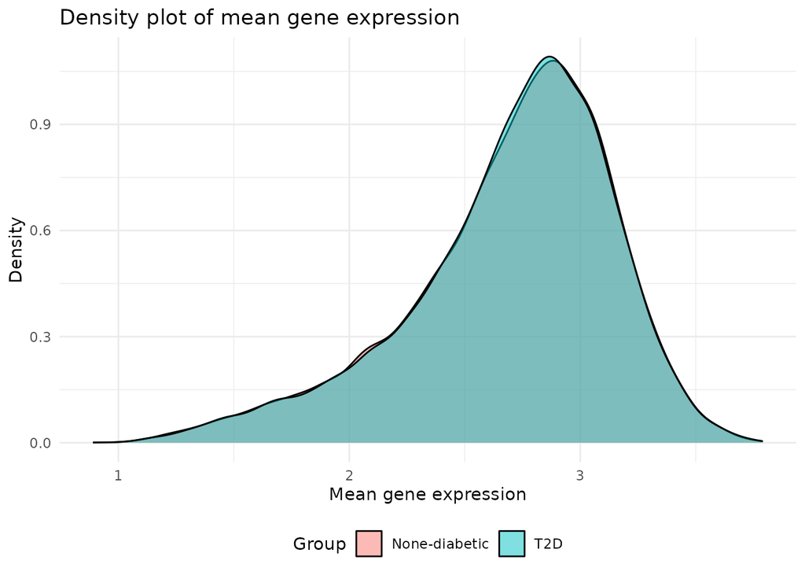

```r
combined_density_plot <- combined_stats |>
  ggplot(aes(x = mean, fill = group)) +
  geom_density(alpha = 0.5) +
  theme_minimal() +
  theme(legend.position = "bottom") +
  labs(title = "Density plot of mean gene expression",
       x = "Mean gene expression",
       y = "Density",
       fill = "Group")

combined_density_plot
```

```r
ggsave("../results/04_combined_density_plot.png", combined_density_plot)
```

Boxplot of the mean gene expression:

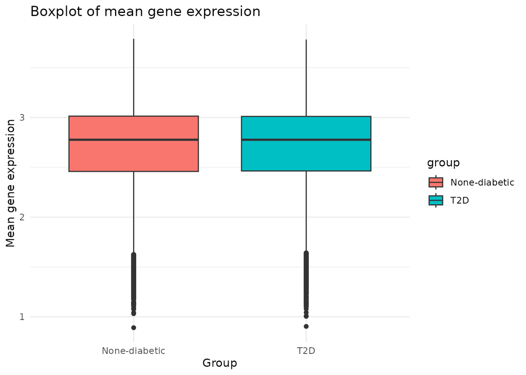

```r
combined_boxplot <- combined_stats |>
  ggplot(aes(x = group, y = mean, fill = group)) +
  geom_boxplot() +
  theme_minimal() +
  labs(title = "Boxplot of mean gene expression",
       x = "Group",
       y = "Mean gene expression")

combined_boxplot
```

```r
ggsave("../results/04_combined_boxplot.png", combined_boxplot)
```

Side-by-side histograms of the mean gene expression:

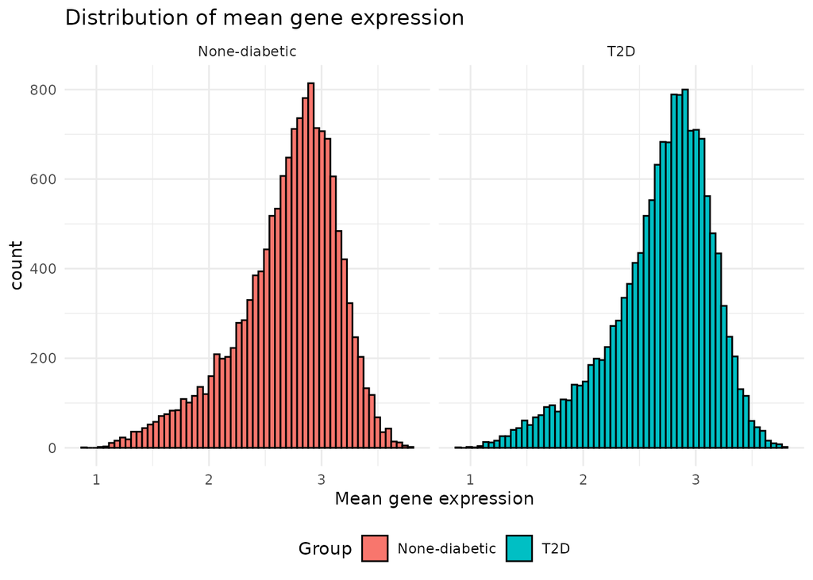

```r
combined_histogram <- ggplot(combined_stats, aes(x = mean, fill = group)) +
  geom_histogram(bins = 60,
                 color = "black") +
  facet_wrap(~group) +
  theme_minimal() +
  theme(legend.position = "bottom") +
  labs(title = "Distribution of mean gene expression",
       x = "Mean gene expression",
       fill = "Group")

combined_histogram
```

```r
ggsave("../results/04_combined_histogram.png", combined_histogram)
```

## Conclusion

Both data sets contain 14481 different genes but differ in sample size as there are 9 T2D samples and 54 control samples.

Further statistical analyses will be performed combined with a gene selection to determine whether the genes differ systematically and significantly between the groups.